# IODS course project

Laura Hekanaho

# My statement

*I have a feeling this course is going to be a bit challenging* [this is my github link](https://github.com/laurahek/IODS-project)

Please do not worry about my chapter 2 missing from here; I did the earleir exercises with my home PC but this week I am working with my laptop and there is a problem knitting chapter 2 from my laptop because the file directories I’ve used there are for my home PC…

**Here begins Week 3**

*Data Wrangling*

The Data Wrangling was done in the file create_students.R

*Logistic Regression*

Using alc_data

Visualizing data

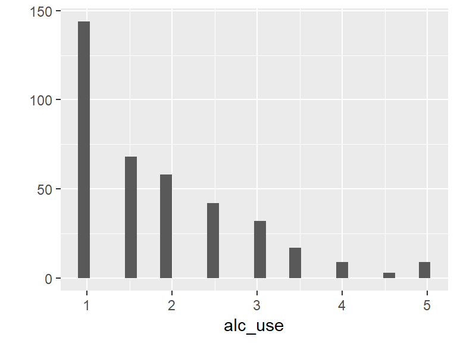

```r
alc_data <- read.csv("Z:\\alc_data", header=TRUE)
library(ggplot2)

qplot(alc_use,data=alc_data)
```

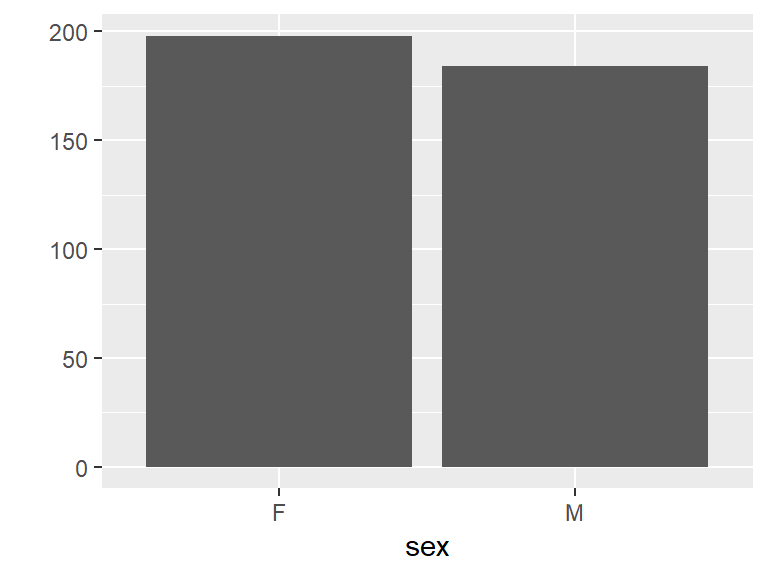

```r
qplot(sex,data=alc_data)
```

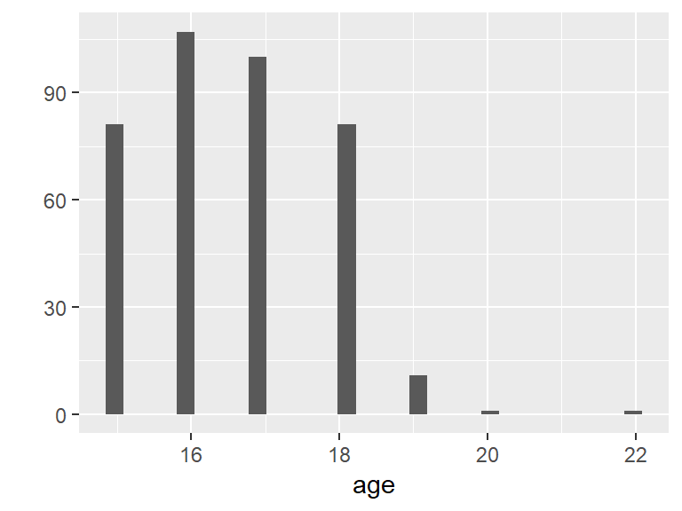

```r
qplot(age,data=alc_data)
```

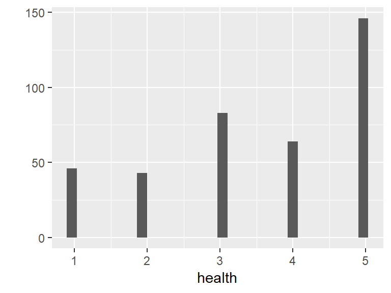

```r
qplot(health,data=alc_data)
```

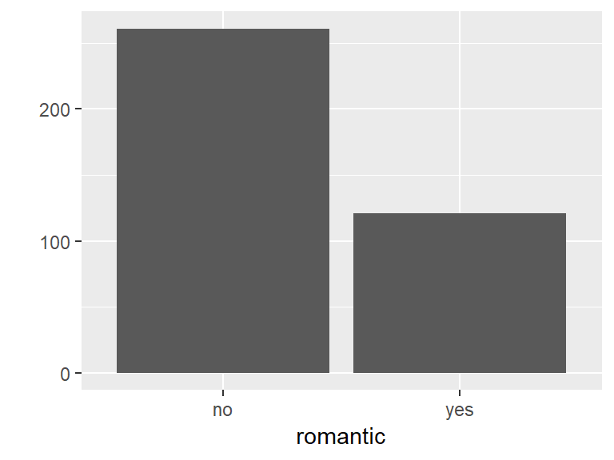

```r
qplot(romantic,data=alc_data)
```

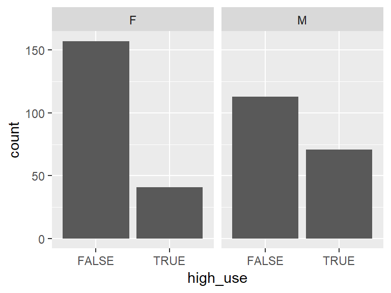

```r
g2 <- ggplot(alc_data, aes(high_use))
g2 + facet_wrap("sex") + geom_bar()
```

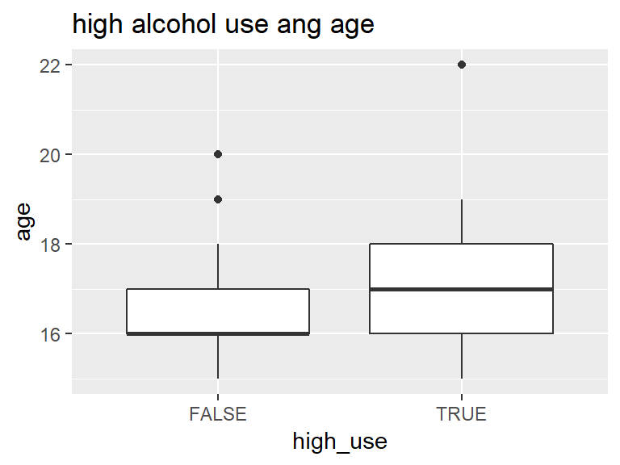

```r
g2 <- ggplot(alc_data, aes(x = high_use, y = age))
g2 + geom_boxplot() + ylab("age")+ggtitle("high alcohol use ang age")
```

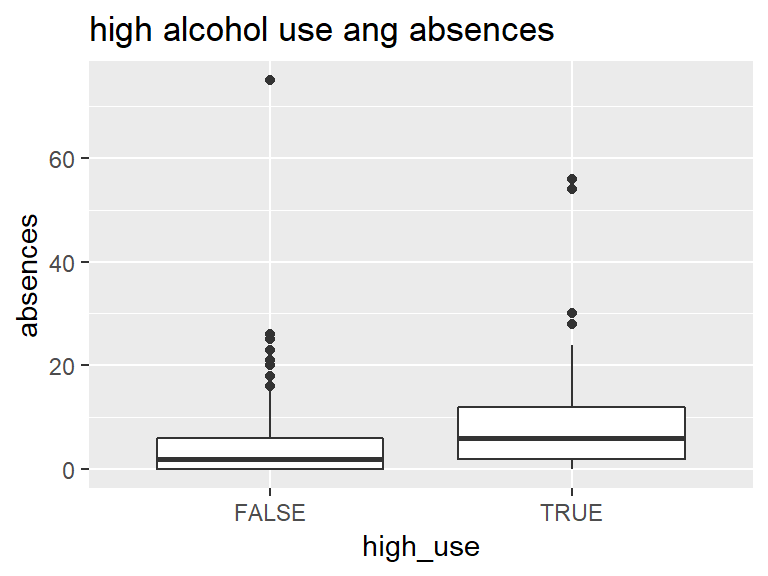

```r
g3 <- ggplot(alc_data, aes(x=high_use, y=absences))
g3 + geom_boxplot() + ylab("absences")+ggtitle("high alcohol use ang absences")
```

```r
table(alc_data$high_use,alc_data$sex)
```

```
##
##           F   M
##   FALSE 157 113
##   TRUE   41  71
```

```r
table(alc_data$high_use,alc_data$romantic)
```

```
##
##          no yes
##   FALSE 182  88
##   TRUE   79  33
```

```r
alc_data <- read.csv("Z:\\alc_data", header=TRUE)

library(tidyr); library(dplyr); library(ggplot2)
gather(alc_data) %>% glimpse
```

```
## Observations: 13,370
## Variables: 2
## $ key   <chr> "school", "school", "school", "school", "school", "schoo...
## $ value <chr> "GP", "GP", "GP", "GP", "GP", "GP", "GP", "GP", "GP", "G...
```

```r
glimpse(alc_data)
```

```
## Observations: 382
## Variables: 35
## $ school     <fct> GP, GP, GP, GP, GP, GP, GP, GP, GP, GP, GP, GP, GP,...
## $ sex        <fct> F, F, F, F, F, M, M, F, M, M, F, F, M, M, M, F, F, ...
## $ age        <int> 18, 17, 15, 15, 16, 16, 16, 17, 15, 15, 15, 15, 15,...
## $ address    <fct> U, U, U, U, U, U, U, U, U, U, U, U, U, U, U, U, U, ...
## $ famsize    <fct> GT3, GT3, LE3, GT3, GT3, LE3, LE3, GT3, LE3, GT3, G...
## $ Pstatus    <fct> A, T, T, T, T, T, T, A, A, T, T, T, T, T, A, T, T, ...
## $ Medu       <int> 4, 1, 1, 4, 3, 4, 2, 4, 3, 3, 4, 2, 4, 4, 2, 4, 4, ...
## $ Fedu       <int> 4, 1, 1, 2, 3, 3, 2, 4, 2, 4, 4, 1, 4, 3, 2, 4, 4, ...
## $ Mjob       <fct> at_home, at_home, at_home, health, other, services,...
## $ Fjob       <fct> teacher, other, other, services, other, other, othe...
## $ reason     <fct> course, course, other, home, home, reputation, home...
## $ nursery    <fct> yes, no, yes, yes, yes, yes, yes, yes, yes, yes, ye...
## $ internet   <fct> no, yes, yes, yes, no, yes, yes, no, yes, yes, yes,...
```

[output cut: 22 more lines]

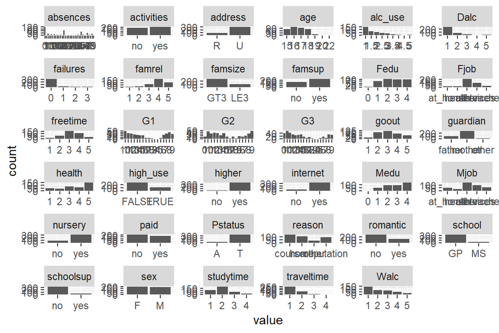

```r
gather(alc_data) %>% ggplot(aes(value)) + facet_wrap("key", scales = "free")+geom_bar()
```

```r
alc_data %>% group_by(sex) %>% summarise(count = n())
```

```
## # A tibble: 2 x 2
##   sex   count
##   <fct> <int>
## 1 F       198
## 2 M       184
```

```r
alc_data <- read.csv("Z:\\alc_data", header=TRUE)
m <- glm(high_use ~ sex + age + romantic + absences, data = alc_data, family = "binomial")
print(m)
```

```
##
## Call:  glm(formula = high_use ~ sex + age + romantic + absences, family = "binomial",
##     data = alc_data)
##
## Coefficients:
## (Intercept)         sexM          age  romanticyes     absences
##    -4.54258      0.99159      0.16915     -0.29584      0.07283
##
## Degrees of Freedom: 381 Total (i.e. Null);  377 Residual
## Null Deviance:       462.2
## Residual Deviance: 422.2     AIC: 432.2
```

```r
summary(m)
```

```
##
## Call:
## glm(formula = high_use ~ sex + age + romantic + absences, family = "binomial",
##     data = alc_data)
##
## Deviance Residuals:
##     Min       1Q   Median       3Q      Max
## -2.7179  -0.8456  -0.6286   1.0823   2.1893
##
## Coefficients:
##             Estimate Std. Error z value Pr(>|z|)
## (Intercept) -4.54258    1.70433  -2.665  0.00769 **
## sexM         0.99159    0.24303   4.080 4.50e-05 ***
## age          0.16915    0.10226   1.654  0.09810 .
## romanticyes -0.29584    0.26585  -1.113  0.26579
## absences     0.07283    0.01828   3.983 6.79e-05 ***
## ---
## Signif. codes:  0 '***' 0.001 '**' 0.01 '*' 0.05 '.' 0.1 ' ' 1
##
## (Dispersion parameter for binomial family taken to be 1)
##
##     Null deviance: 462.21  on 381  degrees of freedom
## Residual deviance: 422.16  on 377  degrees of freedom
## AIC: 432.16
##
## Number of Fisher Scoring iterations: 4
```

```r
coef(m)
```

```
## (Intercept)        sexM         age romanticyes    absences
## -4.54258123  0.99158774  0.16915207 -0.29584023  0.07282766
```

```r
OR <- coef(m) %>% exp
CI <- confint(m) %>% exp
cbind(OR, CI)
```

```
##                     OR        2.5 %   97.5 %
## (Intercept) 0.01064589 0.0003570945 0.290015
## sexM        2.69551085 1.6842578252 4.375275
## age         1.18430022 0.9701859445 1.450229
## romanticyes 0.74390627 0.4371001910 1.242806
## absences    1.07554516 1.0398995842 1.116863
```

First from the summary of the model we see that sex and absences are significant variables, but romantic and age are not. Thus we shall only interpret the coefficients for sex and absences.

We turn to the ORs for intepretation and find that the odds for men to have high alcohol use are 2.7 [1.7, 4.4] times greater than for females. With absences, for every one-unit increase on the absence scale, the odds of high alcohol use are 1.07 [1.04, 1.11] greater, which may at first seem like a small difference but we need to remember that absences is a contintuous variable and one unit increase is a small unit. In sum, sex and absences are significant predictors for high alcohol use.

Next I added the probabilities to the data and for the selected variables took a closer look and then created a table for the predictions and explored the predictions

```r
alc_data <- read.csv("Z:\\alc_data", header=TRUE)
probabilities <- predict(m, type = "response")
alc_data <- mutate(alc_data, probability = probabilities)
alc_data <- mutate(alc_data, prediction = probability > 0.5)
select(alc_data, age, absences, sex, romantic, high_use, probability, prediction) %>% tail(10)
```

```
##     age absences sex romantic high_use probability prediction
## 373  19        0   M       no    FALSE   0.4165131      FALSE
## 374  18       14   M       no     TRUE   0.6255870       TRUE
## 375  18        2   F       no    FALSE   0.2055128      FALSE
## 376  18        7   F      yes    FALSE   0.2168887      FALSE
## 377  19        0   F       no    FALSE   0.2093758      FALSE
## 378  18        0   F       no    FALSE   0.1827473      FALSE
## 379  18        0   F       no    FALSE   0.1827473      FALSE
## 380  18        0   F       no    FALSE   0.1827473      FALSE
## 381  17        3   M       no     TRUE   0.3877155      FALSE
## 382  18        0   M       no     TRUE   0.3760716      FALSE
```

```r
table(high_use = alc_data$high_use, prediction = alc_data$prediction)
```

```
##         prediction
## high_use FALSE TRUE
##    FALSE   261    9
##    TRUE     88   24
```

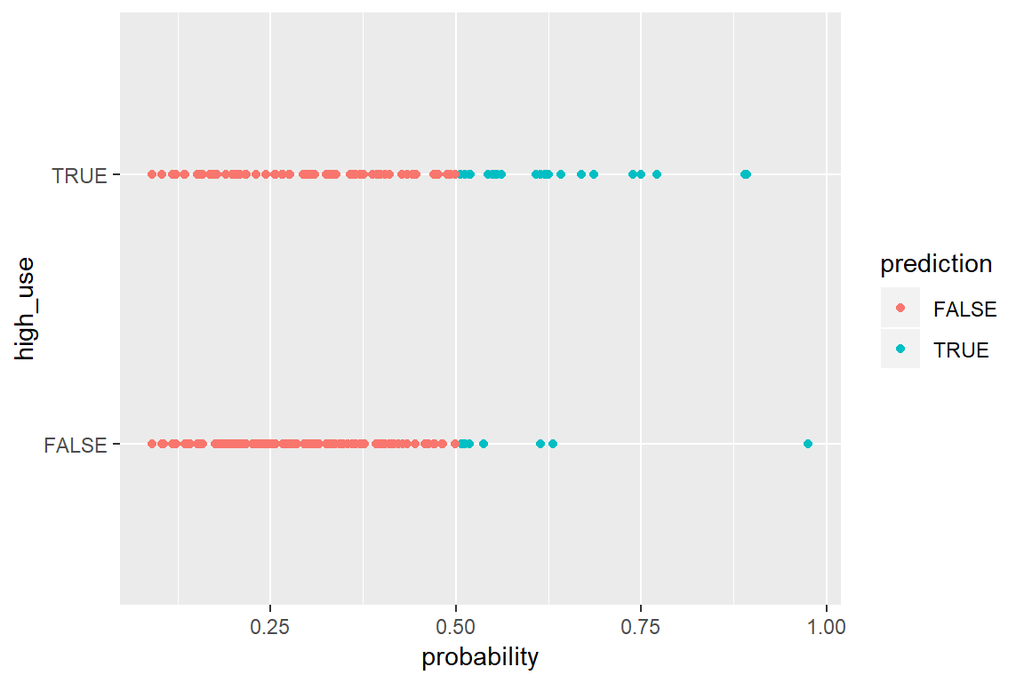

```r
library(ggplot2)
g <- ggplot(alc_data, aes(x = probability, y = high_use, col = prediction))
g + geom_point()
```

```r
table(high_use = alc_data$high_use, prediction = alc_data$prediction)
```

```
##         prediction
## high_use FALSE TRUE
##    FALSE   261    9
##    TRUE     88   24
```